# Experiment_Preprocessing

Delphine Potier / Mathis Nozais / Saran Pankaew

# to do before publish

```r
#change all path to data showing my environment (NAS...) mettre lien à partir de Workspace ou il dowloaderont les fichier source (fastq et objet R)
```

# Loading the first experiment

Demultiplexing HTO

## Demultiplexing results

### Cells classification

### Violinplot (features)

### Violinplot (HTO counts)

## tSNEs based on HTO

### HTO margin

### Ridge plots

**Visualize enrichment for selected HTOs with ridge plots**

## Sample Information

The analysis will be run on the sample 1 (181031).

During the sample loading, we filter cells that do not pass the following filters.  
Here are the description of those parameters in the Seurat *CreateSeuratObject* function:

- min.genes: Include cells where at least 200 genes are detected
- min.cells: Include genes with detected expression in at least 3 cells

## Mitochondrial percentage versus nFeatures

## UMAP

# Loading the second experiment

## Demultiplexing results

### Cells classification

### Violinplot (features)

### Violin plots (HTO counts)

## tSNEs based on HTO

### HTO margin

### Ridge plots

**Visualize enrichment for selected HTOs with ridge plots**

## Sample Information

The analysis will be run on the sample 2 (190211).

## Mitochondrial percentage versus nFeatures

## UMAP

# Merging our two experiments

## Integrating the 2 seurat objects with seurat integration (cca)

```r
# Gene selection for input to CCA
FindVariableFeatures(object = Seurat1,
        selection.method = "vst", nfeatures = 2000, verbose = FALSE)
```

```
## An object of class Seurat
## 13758 features across 3777 samples within 2 assays
## Active assay: RNA (13750 features)
##  1 other assay present: HTO
##  3 dimensional reductions calculated: tsne, pca, umap
```

```r
FindVariableFeatures(object = Seurat2,
        selection.method = "vst", nfeatures = 2000, verbose = FALSE)
```

```
## An object of class Seurat
## 15829 features across 10135 samples within 3 assays
## Active assay: RNA (15815 features)
##  2 other assays present: HTO, ADT
##  3 dimensional reductions calculated: tsne, pca, umap
```

```r
exp.anchors <- FindIntegrationAnchors(object.list = c(Seurat2,Seurat1), dims = 1:30)
gene1 <- rownames(GetAssayData(Seurat1, assay = "RNA", slot = "data" ))
gene2 <- rownames(GetAssayData(Seurat2, assay = "RNA", slot = "data" ))
common_genes <- Reduce(intersect, list(gene1,gene2))

exp1.2.integrated <- IntegrateData(anchorset = exp.anchors, features.to.integrate = common_genes,dims = 1:30)
```

We identified **13750** expressed in sample1 and **15815** expressed in sample2. **13631** are in common in this two set and will the integrated in the merged and corrected object.

# Analysis part

## Sample Information

The analysis will be run on the sample MYC_PTEN_01 (181031 & 190211).

During the sample loading, we filter cells that do not pass the following filters. We also filter cells that are detected as human/mouse multiplet using their barcodes.  
Here are the description of those parameters in the Seurat *CreateSeuratObject* function:

- min.genes: Include cells where at least this many genes are detected
- min.cells: Include genes with detected expression in at least this many cells

```r
# Affiche les parametres
Filter_parameters <- data.frame()
Filter_parameters["Value", "min.cells"] <- 3
Filter_parameters["Value", "min.genes"] <- 200
kable(Filter_parameters, "html", align = "c") %>% kable_styling(bootstrap_options = c("striped", "hover"))
```

|  | min.cells | min.genes |
| --- | --- | --- |
| Value | 3 | 200 |

After those filters, and merging MYC_PTEN_01 and MYC_PTEN02 the remaining cell number is **13912**.

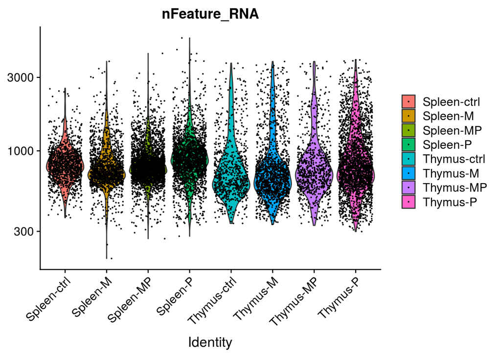

```r
### add Exp1 cell identity (181031)
#add Exp1 cell identity
HTO_cr6 <- intersect(paste0(row.names(subset(Seurat1@meta.data, MULTI_ID == "Spleen-ctrl" )),"_2"),colnames(x = exp1.2.integrated))
HTO_ct6 <- intersect(paste0(row.names(subset(Seurat1@meta.data, MULTI_ID == "Thymus-ctrl" )),"_2"),colnames(x = exp1.2.integrated))
HTO_mr6 <- intersect(paste0(row.names(subset(Seurat1@meta.data, MULTI_ID == "Spleen-M" )),"_2"),colnames(x = exp1.2.integrated))
HTO_mt6 <- intersect(paste0(row.names(subset(Seurat1@meta.data, MULTI_ID == "Thymus-M" )),"_2"),colnames(x = exp1.2.integrated))
HTO_pr6 <- intersect(paste0(row.names(subset(Seurat1@meta.data, MULTI_ID == "Spleen-P" )),"_2"),colnames(x = exp1.2.integrated))
HTO_pt6 <- intersect(paste0(row.names(subset(Seurat1@meta.data, MULTI_ID == "Thymus-P" )),"_2"),colnames(x = exp1.2.integrated))
HTO_pmr6 <- intersect(paste0(row.names(subset(Seurat1@meta.data, MULTI_ID == "Spleen-MP" )),"_2"),colnames(x = exp1.2.integrated))
HTO_pmt6 <- intersect(paste0(row.names(subset(Seurat1@meta.data, MULTI_ID == "Thymus-MP" )),"_2"),colnames(x = exp1.2.integrated))

### add Exp2 cell identity (190211)
HTO_cr2 <- intersect(paste0(row.names(subset(Seurat2@meta.data, MULTI_ID == "Spleen-ctrl" )),"_1"),colnames(x = exp1.2.integrated))
HTO_ct2 <- intersect(paste0(row.names(subset(Seurat2@meta.data, MULTI_ID== "Thymus-ctrl" )),"_1"),colnames(x = exp1.2.integrated))
HTO_mr2 <- intersect(paste0(row.names(subset(Seurat2@meta.data, MULTI_ID== "Spleen-M" )),"_1"),colnames(x = exp1.2.integrated))
HTO_mt2 <- intersect(paste0(row.names(subset(Seurat2@meta.data, MULTI_ID== "Thymus-M" )),"_1"),colnames(x = exp1.2.integrated))
HTO_pr2 <- intersect(paste0(row.names(subset(Seurat2@meta.data, MULTI_ID== "Spleen-P" )),"_1"),colnames(x = exp1.2.integrated))
HTO_pt2 <- intersect(paste0(row.names(subset(Seurat2@meta.data, MULTI_ID== "Thymus-P" )),"_1"),colnames(x = exp1.2.integrated))
HTO_pmr2 <- intersect(paste0(row.names(subset(Seurat2@meta.data, MULTI_ID== "Spleen-MP" )),"_1"),colnames(x = exp1.2.integrated))
HTO_pmt2 <- intersect(paste0(row.names(subset(Seurat2@meta.data, MULTI_ID== "Thymus-MP" )),"_1"),colnames(x = exp1.2.integrated))



exp1.2.integrated@meta.data$HTO = "nothing"
exp1.2.integrated@meta.data[HTO_cr2,]$HTO = "WT spleen"
exp1.2.integrated@meta.data[HTO_ct2,]$HTO = "WT thymus"
exp1.2.integrated@meta.data[HTO_cr6,]$HTO = "WT spleen"
exp1.2.integrated@meta.data[HTO_ct6,]$HTO = "WT thymus"
exp1.2.integrated@meta.data[HTO_pr2,]$HTO = "PTEN- spleen"
exp1.2.integrated@meta.data[HTO_pt2,]$HTO = "PTEN- thymus"
exp1.2.integrated@meta.data[HTO_pr6,]$HTO = "PTEN- spleen"
exp1.2.integrated@meta.data[HTO_pt6,]$HTO = "PTEN- thymus"
exp1.2.integrated@meta.data[HTO_mr2,]$HTO = "MYC- spleen"
exp1.2.integrated@meta.data[HTO_mt2,]$HTO = "MYC- thymus"
exp1.2.integrated@meta.data[HTO_mr6,]$HTO = "MYC- spleen"
exp1.2.integrated@meta.data[HTO_mt6,]$HTO = "MYC- thymus"
exp1.2.integrated@meta.data[HTO_pmr2,]$HTO = "Myc- PTEN- spleen"
exp1.2.integrated@meta.data[HTO_pmt2,]$HTO = "Myc- PTEN- thymus"
exp1.2.integrated@meta.data[HTO_pmr6,]$HTO = "Myc- PTEN- spleen"
exp1.2.integrated@meta.data[HTO_pmt6,]$HTO = "Myc- PTEN- thymus"

HTO_thymus = c(HTO_ct2,HTO_mt2,HTO_pt2,HTO_pmt2,HTO_ct6,HTO_mt6,HTO_pt6,HTO_pmt6)
HTO_spleen = c(HTO_cr2,HTO_mr2,HTO_pr2,HTO_pmr2,HTO_cr6,HTO_mr6,HTO_pr6,HTO_pmr6)

identified <- c(HTO_thymus,HTO_spleen)
VlnPlot(exp1.2.integrated,features = "nFeature_RNA",pt.size = 0.1, log = TRUE,  group.by = "MULTI_ID")
```

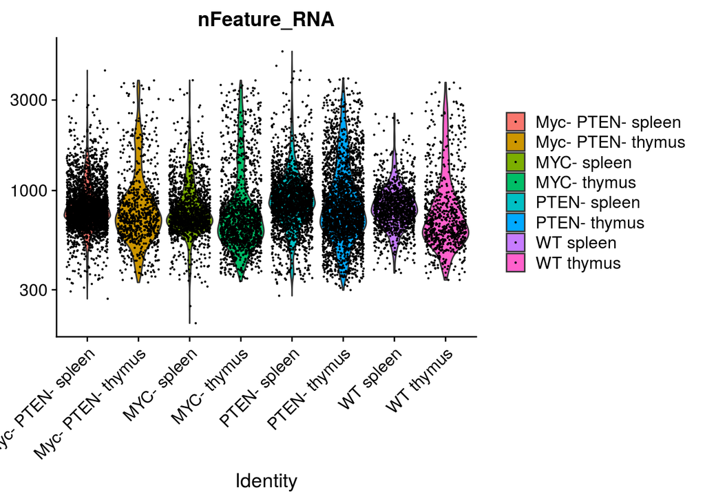

```r
VlnPlot(exp1.2.integrated,features = "nFeature_RNA",pt.size = 0.1, log = TRUE,  group.by = "HTO")
```

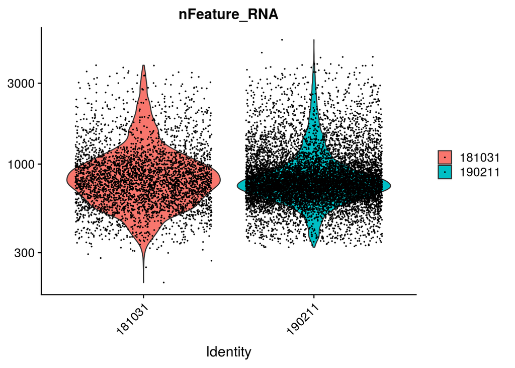

```r
VlnPlot(exp1.2.integrated,features = "nFeature_RNA",pt.size = 0.1, log = TRUE,  group.by = "orig.ident")
```

```r
Seurat <- exp1.2.integrated
```

## UMAP and clustering parameter